# Exploring the BRFSS data

## Setup

### Load packages

```r
library(ggplot2)
library(dplyr)
```

### Load data

```r
load("brfss2013.RData")
```

## Part 1: Data

they collected surveillance data on risk behaviors through monthly telephone interview. The data was collected by observation. The data was not collected by experiment study. when they collect the data of two variables, they don’t do it like an experiment study which make all the other variables the same. they just collect the data which they observed. so we can only get the relation between variables. we can’t know the causation between variables in the data. since they collecting the data of random samples in the US, so the relation between variables can be generalize to all the us population. * * *

## Part 2: Research questions

**Research quesion 1:** what’s the relation between smoking and drinking alcohol. There are some people around me, some of them like both somking and drinking, and some of them don’t like both somking and drinking. So i’m interested in the relation between the Frequency Of Days Now Smoking and Binge Drinking.

**Research quesion 2:** what’s the relation between exercise and vegetables consumption. I like exercise and bodybuilding. So i care about the nutrition about my food. I think I eat more vegetables than the others. But Is that ture? How about the others which like exercise? Do they eat more vegetables than the others?

**Research quesion 3:** what’s the relation between age and drinking alcohol. what’s the age we like drinking alcohol most? what do u guess? age 18-25 or 25 - 30?

## Part 3: Exploratory data analysis

**Research quesion 1:**

here some infomation about the variables.

smokday2: Frequency Of Days Now Smoking Do you now smoke cigarettes every day, some days, or not at all?

drnk3ge5:Binge Drinking Considering all types of alcoholic beverages, how many times during the past 30 days did you have 5 or more drinks for men or 4 or more drinks for women on an occasion?

first plot the relation between smokink and drinking

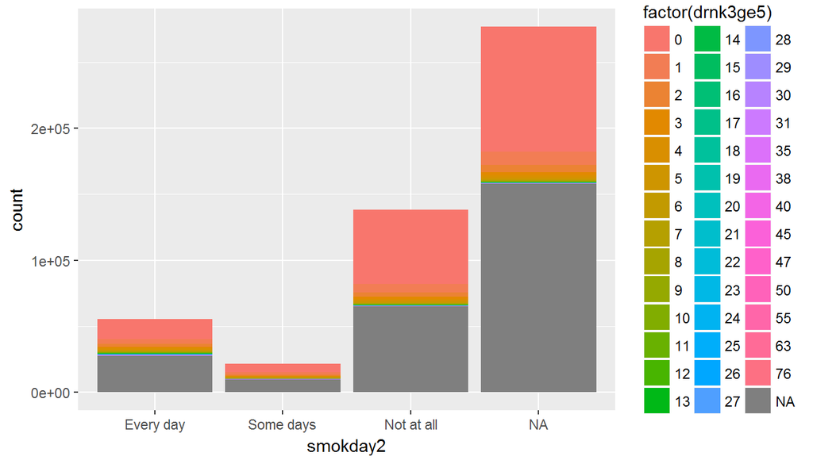

```r
ggplot(brfss2013, aes(x = smokday2, fill = factor(drnk3ge5))) + geom_bar()
```

the graphic above is reall not easy to identify. so make a new variable “like_drink” .if drnk3ge5 is greater than 0, then mark this variable “like”.

```r
brfss2013 <- brfss2013 %>%filter(!is.na(drnk3ge5)) %>%  mutate(like_drink = ifelse(drnk3ge5 > 0,"like", "don't like"))
brfss2013 %>% group_by(smokday2) %>% summarise(jpro = sum(like_drink == "like") / n())
```

```
## # A tibble: 4 x 2
##     smokday2      jpro
##       <fctr>     <dbl>
## 1  Every day 0.4540942
## 2  Some days 0.4502805
## 3 Not at all 0.2309312
## 4         NA 0.2030654
```

plot this relation

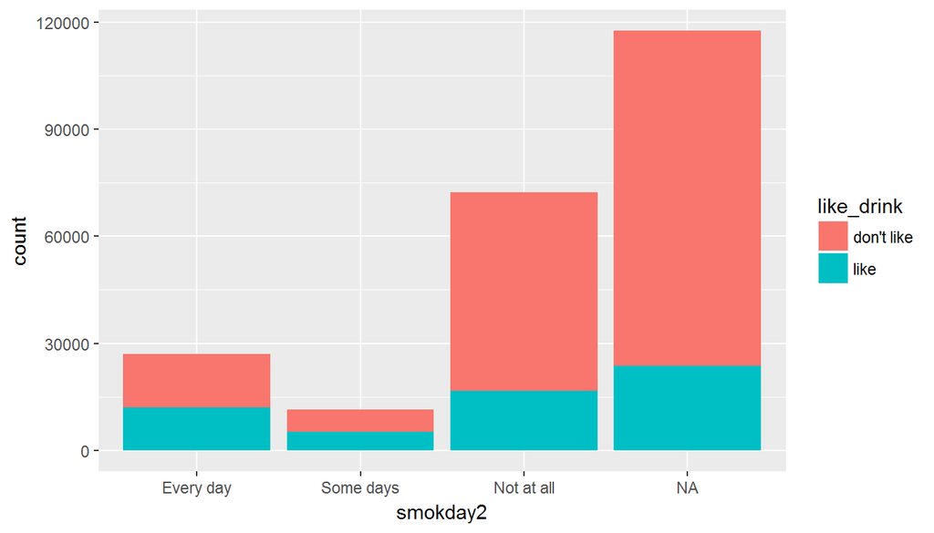

```r
brfss2013 %>% filter(!is.na(X_drnkdy4)) %>% ggplot(aes(x = smokday2, fill = like_drink)) + geom_bar()
```

form the picture, we can see that people who like smoking will be more likely to drinking.

**Research quesion 2:**

_vegesum: Total Vegetables Consumed Per Day

exerany2: Exercise In Past 30 Days During the past month, other than your regular job, did you participate in any physical activities or exercises such as running, calisthenics, golf, gardening, or walking for exercise?

first find the varibles’ name in the rdata.

```r
grep("vegesum",names(brfss2013),value = TRUE)
```

```
## [1] "X_vegesum"
```

```r
grep("exerany2",names(brfss2013),value = TRUE)
```

```
## [1] "exerany2"
```

will the people who like ersercise consume more vegetables?

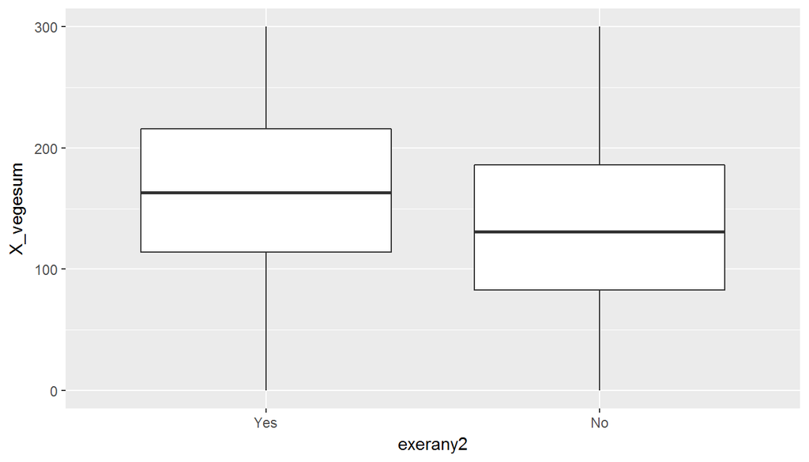

```r
brfss2013 %>% filter(!is.na(X_vegesum)) %>% filter(!is.na(exerany2))%>% ggplot(aes(x = exerany2, y = X_vegesum)) + geom_boxplot() + scale_y_continuous(limits = c(0,300))
```

yes! it seems the people who like ersercise will be more likely to consume more vegetables.

**Research quesion 3:**

there are some infomation about the variables.

_ageg5yr: Reported Age In Five-Year Age Categories Calculated Variable

drnk3ge5:Binge Drinking Considering all types of alcoholic beverages, how many times during the past 30 days did you have 5 or more drinks for men or 4 or more drinks for women on an occasion?

first I need find the varibles’ name in the rdata

```r
grep("ageg5yr",names(brfss2013),value = TRUE)
```

```
## [1] "X_ageg5yr"
```

```r
grep("drnk3ge5",names(brfss2013),value = TRUE)
```

```
## [1] "drnk3ge5"
```

ignore all the “Na” obervations in the ageg5yr variable and drnk3ge5 variable. And story the variables in age_and_drink

```r
age_and_drink <- brfss2013 %>% select(X_ageg5yr, drnk3ge5) %>%  filter(!is.na(X_ageg5yr)) %>% filter(!is.na(drnk3ge5))
```

then make a boxplot to see the big picture of the relation between age and drinking alcolho.

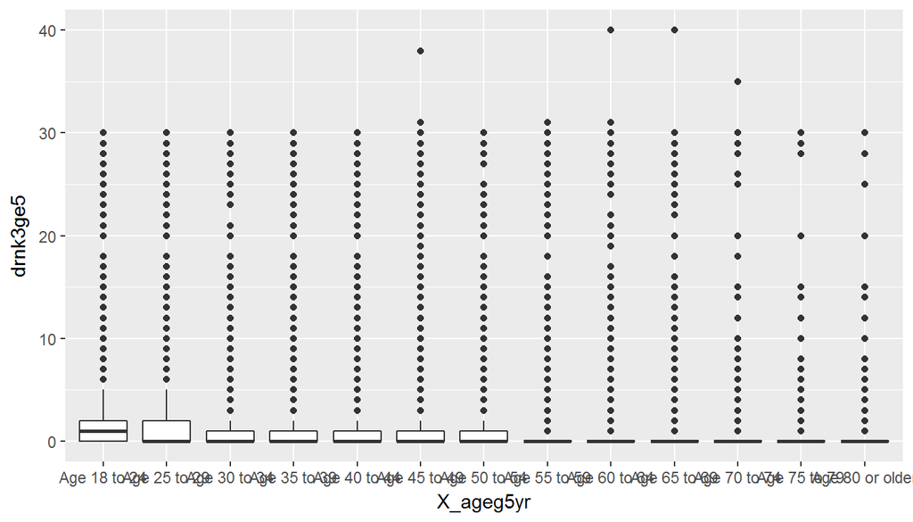

```r
age_and_drink %>% ggplot(aes(x = X_ageg5yr, y = drnk3ge5)) + geom_boxplot() + scale_y_continuous(limits = c(0,40))
```

now compute the IQR mean median and stander deviation

```r
 age_and_drink %>% group_by(X_ageg5yr) %>% summarise(IQR = IQR(drnk3ge5), mean = mean(drnk3ge5), median = median(drnk3ge5), sd = sd(drnk3ge5))
```

```
## # A tibble: 13 x 5
##          X_ageg5yr   IQR      mean median       sd
##             <fctr> <dbl>     <dbl>  <dbl>    <dbl>
##  1    Age 18 to 24     2 2.1131100      1 3.970385
##  2    Age 25 to 29     2 1.7739836      0 3.980229
##  3    Age 30 to 34     1 1.4585032      0 3.610239
##  4    Age 35 to 39     1 1.3487077      0 3.784078
##  5    Age 40 to 44     1 1.2951316      0 3.795576
##  6    Age 45 to 49     1 1.2796982      0 3.980906
##  7    Age 50 to 54     1 1.2131297      0 3.923372
##  8    Age 55 to 59     0 1.0585218      0 3.777195
##  9    Age 60 to 64     0 0.8953998      0 3.660408
## 10    Age 65 to 69     0 0.7284913      0 3.310241
## 11    Age 70 to 74     0 0.5335076      0 2.888737
## 12    Age 75 to 79     0 0.3646498      0 2.339604
## 13 Age 80 or older     0 0.2339243      0 1.952770
```

the extreme value effect the mean vary much,so I need ignore thoes value. make a new data which story the data which the drnk3ge5 varible is in 2 stander deviation.

```r
age_and_drink %>% summarise(mean = mean(drnk3ge5), sd = sd(drnk3ge5))
```

```
##      mean       sd
## 1 1.10184 3.615594
```

```r
age_and_drink_in2 <- age_and_drink %>% filter(drnk3ge5 <= 1.10184 + 2 * 3.615594)
```

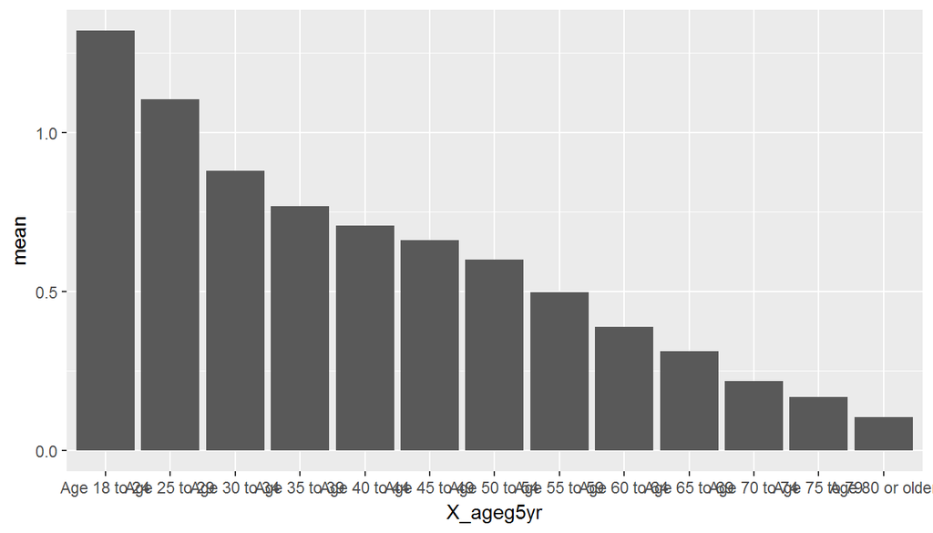

```r
age_and_drink_in2 %>% group_by(X_ageg5yr) %>% summarise(mean = mean(drnk3ge5)) %>% ggplot(aes(x = X_ageg5yr, y = mean )) + geom_bar(stat="identity")
```

From the graph,as the we become older, we are less likely to have 5 drinks on one occasion.we like drinking alcohol most in age 18 - 25.